# AllLife Bank Customer Segmentation

#### Multi-variate

"Total_visits_online" showed the most clustering potential in the pair plot. I would like to compare it to all possible pairs of the other variables using a scatter plot with "Total_visits_online" as the hue, to see if additional clusters emerge.

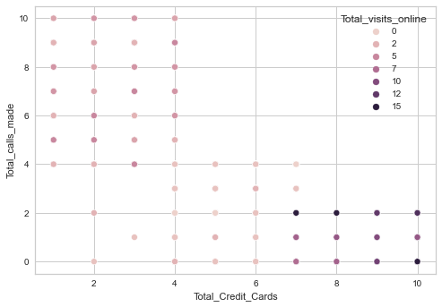

```python
sns.scatterplot(y = "Total_calls_made", x = "Total_Credit_Cards", hue = "Total_visits_online", data = df)
```

##### Observations

- I see at least 3 clusters here
- One has high visits online, low calls made and high number of credit cards
- One has low calls made, moderate number of credit cards, and low number of visits
- One has low number of credit cards, high calls made, and moderate number of visits

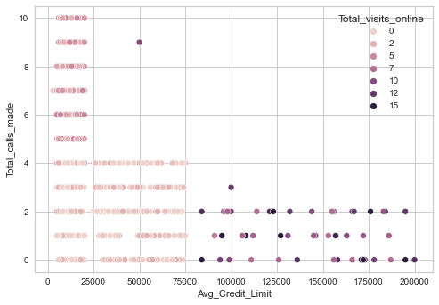

```python
sns.scatterplot(y = "Total_calls_made", x = "Avg_Credit_Limit", hue = "Total_visits_online", data = df)
```

##### Observations

- At least three groups
- One has high credit limits, high visits, and low calls made
- One has low to moderate credit limit, with low visits and low calls
- The final group has low credit limit, high calls made, and moderate visits

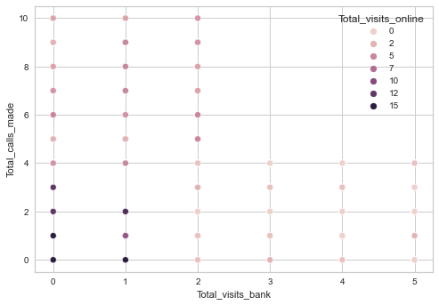

```python
sns.scatterplot(y = "Total_calls_made", x = "Total_visits_bank", hue = "Total_visits_online", data = df)
```

##### Observations

- At least three clusters
- One has high in-person visits, low calls, and low visits online
- One has low in-person visits, low calls, and high visits online
- The final has high calls, low in-person visits, and moderate visits online

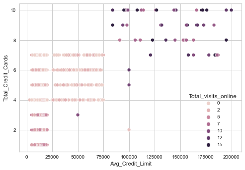

```python
sns.scatterplot(y = "Total_Credit_Cards", x = "Avg_Credit_Limit", hue = "Total_visits_online", data = df)
```

##### Observations

- Three clusters
- One has high credit limit, visits online, and number of credit cards
- One has low to moderate credit limit, moderate number of credit cards, and low visits online
- The final has low credit limit and number of credit cards, with a moderate amount of visits online

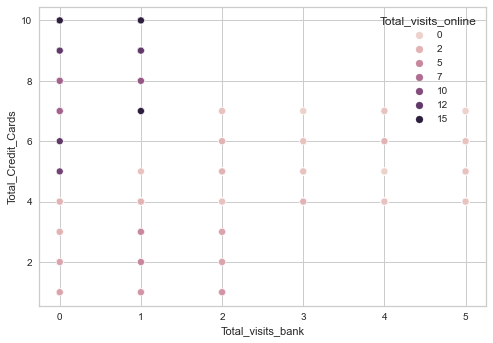

```python
sns.scatterplot(y = "Total_Credit_Cards", x = "Total_visits_bank", hue = "Total_visits_online", data = df)
```

##### Observations

- At least two clusters
- One has high in-person visits and credit cards with low visits online
- The other has low in-person visits and credit cards with a moderate amount of visits online

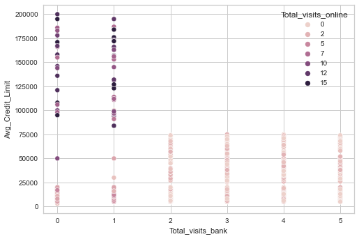

```python
sns.scatterplot(y = "Avg_Credit_Limit", x = "Total_visits_bank", hue = "Total_visits_online", data = df)
```

##### Observations

- I see at least 3 groups
- One has high visits in-person, low credit limit, and low visits online
- One has low visits in-person and credit limit, with a moderate number of visits online
- The final has high credit limit, low visits, and high visits online

### Clustering

- I will try k-means clustering first, attempting with 2-9 clusters in a "for" loop, using Euclidean distances
- I will find the best number of clusters using elbow method and silhouette score
- Next, I will try hierarchical clustering, generate dendograms using several linkage methods, and find the best number of clusters using the dendograms and silhouette score
- Finally, I will compare the best result from each method, and determine the best number and method of clustering
- Since I only have 5 variables, I judge that it is not necessary to perform a feature extraction method like PCA
- For all the above, I will use my scaled dataframe

#### K-Means Clustering

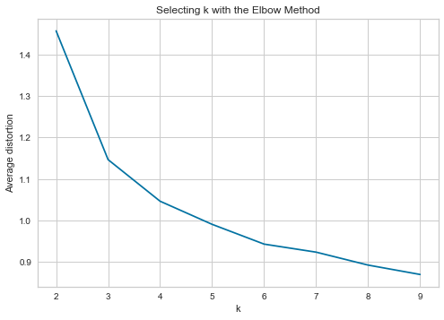

```python
#Finding optimal no. of clusters

clusters=range(2,10)
meanDistortions=[]

for k in clusters:
    model=KMeans(n_clusters=k)
    model.fit(dfScaled)
    prediction=model.predict(dfScaled)
    meanDistortions.append(sum(np.min(cdist(dfScaled, model.cluster_centers_, 'euclidean'), axis=1)) / dfScaled.shape[0])


plt.plot(clusters, meanDistortions, 'bx-')
plt.xlabel('k')
plt.ylabel('Average distortion')
plt.title('Selecting k with the Elbow Method')
```

#### Observations

- There is a major elbow at 3 clusters. Based on my kde plots from above, I feel that I may need more than 3 clusters
- I also see a minor elbow at 4 and 6 clusters
- I will try visualizing with 3, 4 and 6 clusters, and pick the one that comes out best

```python
# Let us first start with k = 3

k3_model=KMeans(3)
k3_model.fit(dfScaled)
prediction=k3_model.predict(dfScaled)

# Append the prediction to both the scaled dataset and the unscaled

dfk3 = df.copy(deep = True)
dfk3Scaled = dfScaled.copy(deep = True)

dfk3["Group"] = prediction
dfk3Scaled["Group"] = prediction
print("Groups Assigned : \n")
dfk3.head()
```

```
Groups Assigned :
```

|  | Avg_Credit_Limit | Total_Credit_Cards | Total_visits_bank | Total_visits_online | Total_calls_made | Group |
| --- | --- | --- | --- | --- | --- | --- |
| 0 | 100000 | 2 | 1 | 1 | 0 | 2 |
| 1 | 50000 | 3 | 0 | 10 | 9 | 1 |
| 2 | 50000 | 7 | 1 | 3 | 4 | 2 |
| 3 | 30000 | 5 | 1 | 1 | 4 | 2 |
| 4 | 100000 | 6 | 0 | 12 | 3 | 0 |

```python
# Next, I will visualize my groups with boxplots

dfk3Clust = dfk3.groupby(['Group'])
dfk3Clust.mean()
```

| Group | Avg_Credit_Limit | Total_Credit_Cards | Total_visits_bank | Total_visits_online | Total_calls_made |
| --- | --- | --- | --- | --- | --- |
| 0 | 141040.000000 | 8.740000 | 0.600000 | 10.900000 | 1.080000 |
| 1 | 12174.107143 | 2.410714 | 0.933036 | 3.553571 | 6.870536 |
| 2 | 33782.383420 | 5.515544 | 3.489637 | 0.981865 | 2.000000 |

```python
dfk3Scaled.boxplot(by='Group', layout = (2,4),figsize=(15,10))
```

[output not shown]

```
array([[<AxesSubplot:title={'center':'Avg_Credit_Limit'}, xlabel='[Group]'>,
        <AxesSubplot:title={'center':'Total_Credit_Cards'}, xlabel='[Group]'>,
        <AxesSubplot:title={'center':'Total_calls_made'}, xlabel='[Group]'>,
        <AxesSubplot:title={'center':'Total_visits_bank'}, xlabel='[Group]'>],
       [<AxesSubplot:title={'center':'Total_visits_online'}, xlabel='[Group]'>,
        <AxesSubplot:>, <AxesSubplot:>, <AxesSubplot:>]], dtype=object)
```

#### Observations

- These groups seem to have a good amount of variation in each variable
- This may be sufficient, but I will check with k = 4 and k = 6
- If the groups are too similar, I will stick with 3 clusters

```python
# k = 4

k4_model=KMeans(4)
k4_model.fit(dfScaled)
prediction=k4_model.predict(dfScaled)

# Append the prediction to both the scaled dataset and the unscaled

dfk4 = df.copy(deep = True)
dfk4Scaled = dfScaled.copy(deep = True)

dfk4["Group"] = prediction
dfk4Scaled["Group"] = prediction
print("Groups Assigned : \n")
dfk4.head()
```

```
Groups Assigned :
```

|  | Avg_Credit_Limit | Total_Credit_Cards | Total_visits_bank | Total_visits_online | Total_calls_made | Group |
| --- | --- | --- | --- | --- | --- | --- |
| 0 | 100000 | 2 | 1 | 1 | 0 | 3 |
| 1 | 50000 | 3 | 0 | 10 | 9 | 1 |
| 2 | 50000 | 7 | 1 | 3 | 4 | 3 |
| 3 | 30000 | 5 | 1 | 1 | 4 | 3 |
| 4 | 100000 | 6 | 0 | 12 | 3 | 2 |

```python
# Next, I will visualize my groups with boxplots

dfk4Clust = dfk4.groupby(['Group'])
dfk4Clust.mean()
```

| Group | Avg_Credit_Limit | Total_Credit_Cards | Total_visits_bank | Total_visits_online | Total_calls_made |
| --- | --- | --- | --- | --- | --- |
| 0 | 31226.315789 | 5.478947 | 4.515789 | 1.010526 | 1.936842 |
| 1 | 12167.420814 | 2.393665 | 0.927602 | 3.574661 | 6.923077 |
| 2 | 141040.000000 | 8.740000 | 0.600000 | 10.900000 | 1.080000 |
| 3 | 35904.522613 | 5.522613 | 2.477387 | 0.969849 | 2.075377 |

```
array([[<AxesSubplot:title={'center':'Avg_Credit_Limit'}, xlabel='[Group]'>,
        <AxesSubplot:title={'center':'Total_Credit_Cards'}, xlabel='[Group]'>,
        <AxesSubplot:title={'center':'Total_calls_made'}, xlabel='[Group]'>,
        <AxesSubplot:title={'center':'Total_visits_bank'}, xlabel='[Group]'>],
       [<AxesSubplot:title={'center':'Total_visits_online'}, xlabel='[Group]'>,
        <AxesSubplot:>, <AxesSubplot:>, <AxesSubplot:>]], dtype=object)
```

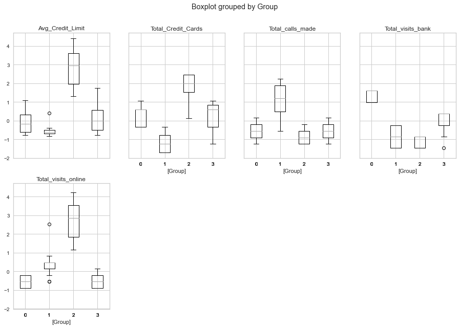

```python
dfk4Scaled.boxplot(by='Group', layout = (2,4),figsize=(15,10))
```